# Final Project (PSTAT 231)

This pattern does not hold in the purple counties.

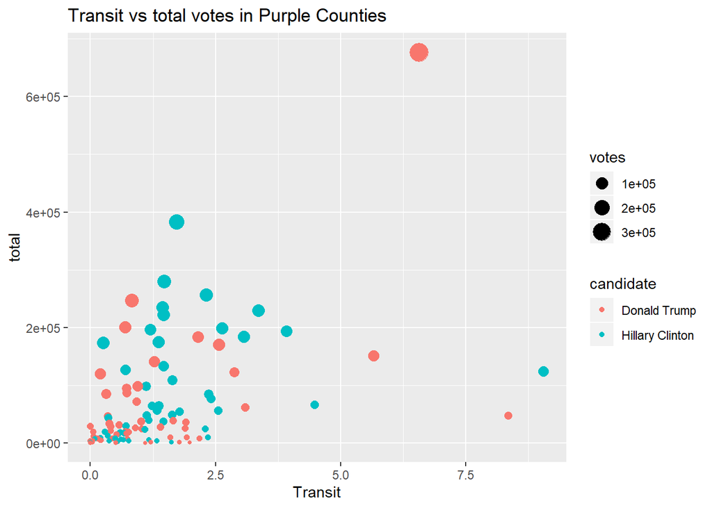

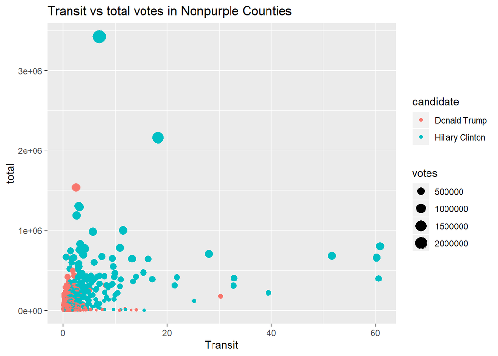

**Analysis**

In the nonpurple counties, low transit and low votes goes to Trump. The separation does not hld in the purple counties.

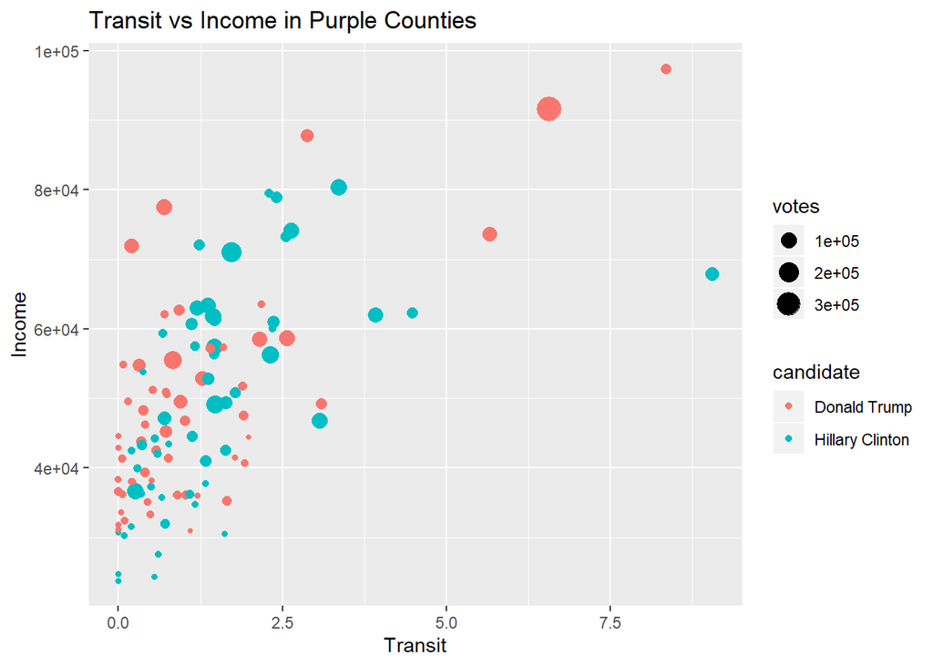

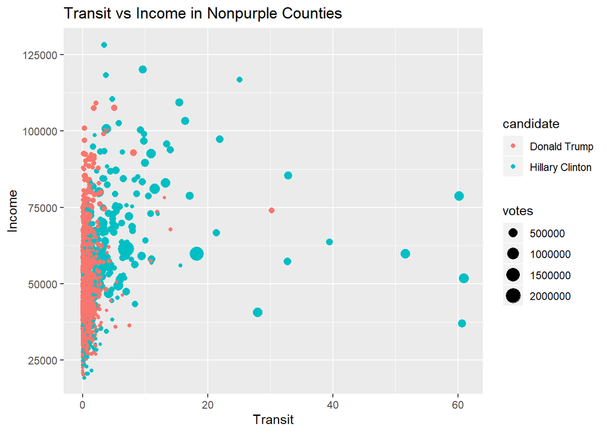

**Analysis**

We see in the nonpurple counties that increasing transit means the county probably goes to Clinton regardless of income. There is no apparant pattern for the purple counties.